# Are University of Utah Students Negatively Affected by the Use of Instagram?

Sameer Khan, Nick Waddups, Luke Schreiber

## Introduction

Social media has become extremely common among university students. With its increasing popularity, many are concerned about its harmful consequences. Several studies have been conducted by health experts, and many point to social media having many negative affects, such as increased anxiety and depression, addiction, body dysmorphia, inability to focus on school or work, and more. Thus begins this study on the affects of social media. The motive of this case study is to find out if University of Utah students are negatively affected by the use of Instagram.

We decided to focus our efforts on studying Instagram over other social media apps because of its popularity, and because the activity of users on Instagram can potentially provide evidence suggesting the existence of body shaming on the platform. Individuals who post pictures of themselves on their accounts may receive more or less attention in the form of followers depending on their body types. To take this further, an individual’s body type may even be a deciding factor in determining whether or not they have pictures of themselves on Instagram accounts in the first place.

Whether Instagram affects users’ abilities to focus on work or school is another important topic to study, since general awareness about the issue can result in people taking responsibility for their content consumption, as well as encouraging further allocation of resources to provide services to help those who struggle with social media. In the case of U of U students, we all have a common and somewhat standard metric of determining performance: GPA. Thus, we will study how time spent on Instagram affects U of U students’ GPA’s. To take this further, whether or not a student even has an Instagram may have an effect on their GPA, so this will be studied as well.

To summarize, this case study will attempt to answer the following questions with regards to University of Utah students:

1. Does the BMI of an individual who has pictures of themselves on their Instagram account have an effect on the number of followers on their account?
2. Does BMI affect whether or not Instagram users post pictures of themselves on their Instagram?
3. Does BMI affect whether or not individuals have an Instagram account?
4. Does the daily time spent on Instagram affect an individual’s GPA?
5. Does having an Instagram account affect an individual’s GPA?

## Data Collection

This study is primarily focused on U of U students’ usage of Instagram, their grades, and their body types. To help answer the questions posed in the introduction, we can gather data about students’ usage of Instagram by asking whether or not respondents post pictures of themselves on their Instagram account, how many followers they have, and how many minutes per day they spend on Instagram. Quantifying respondents grades is very straightforward, since we can simply ask them for their cumulative GPA.

As for respondents’ body types, this is much less simple. Asking respondents to describe their body types is impractical, and perhaps inappropriate. Asking them how they feel about their bodies wouldn’t do us much good either, since a person’s happiness with how they look depends on several factors other than their own body. Ideally, we want qualitative data here. Thus, we decided to collect each respondent’s Body Mass Index (BMI) by asking them for their height and weight. However, this approach isn’t without its flaws. BMI is a measure of body fat based entirely on an individual’s height and weight–it does not account for other factors which play a large role in an individual’s body type, such as their level of physical activity. An athlete with a significant amount of muscle mass could have a higher BMI than someone who leads a more sedentary lifestyle, but this doesn’t mean that the athlete is overweight or less healthy than the individual with a lower BMI and more sedentary lifestyle. Body fat percentage would be a more accurate quantitative variable to describe an individual’s body type. However decided against collecting this, since measuring respondents’ body fat percentages comes with a plethora of impracticalities (we can’t exactly hand surveyees body fat calipers over discord).

We also included some questions that may not necessarily be used to answer the five questions posed in the introduction, but could provide some insight into our sample and the topic being studied. These questions asked about gender, sleep, and whether respondents felt like they spent too much time on Instagram. The survey questions are listed below:

1. What is your cumulative GPA?
2. is your height in feet and inches?
3. What is your gender?
4. How much sleep do you get per night on average?
5. What is your weight in pounds?

The following questions were only posed to surveyees who had an Instagram account:

6. Do you post pictures of yourself on your Instagram account?
7. How many followers do you have on your Instagram account?
8. On average, how many minutes do you spend on Instagram per day?
9. Do you feel like you spend too much time on Instagram?

To gather the data, we created a Google survey with the questions listed below. The survey was posted on the class discord, as well as other U of U affiliated discord servers, such as Data Science UofU, U Physics & Astronomy, and Crimson Gaming. It was also posted to the U’s subreddit, r/uofu. Then, to gather even more samples from U of U students who weren’t necessarily on discord or reddit, we surveyed students on campus by setting up a table in front of the library with treats, asking students who passed by to take our survey.

## Data Analysis

After receiving 136 survey responses, the csv file from the Google form was downloaded and read into R. A non-trivial amount of cleanup was required before all of the data could be used. For example, some survey respondents incorrectly formatted their heights. This was difficult to fix in R, so the csv file was altered manually. Examples of faulty data that was cleansed in R includes non-numeric answers for GPA, time spent on Instagram, or follower count– the responses of these surveyees was dropped by using the “is.na” function in conjunction with other parsing functions. Some of the incorrectly formatted data that was easy to locate and correct in the csv file was done directly in the csv file itself, such as surveyees including units for weight.

Next, the BMI of each respondent needed to be calculated. To do this, the “Height” column was converted from feet and inches to inches. Then, a column for BMI was added, which was found by multiplying weight by 703 and dividing by the height (in inches) squared. From here, the data could be separated into multiple different tables to represent the different groups of this study. There was a table for all respondents, respondents who used Instagram, respondents who used Instagram who posted pictures of themselves on their accounts, and respondents who used Instagram who didn’t post pictures of themselves on their accounts. Now, data analysis can be performed with respect to the questions posed in the introduction.

#### 1) Does the BMI of an individual who has pictures of themselves on their Instagram account have an effect on the number of followers on their account?

To determine whether BMI plays a roll in the number of followers an individual has on their account, given that they post pictures of themselves on their account, linear regression can be used to determine if there’s a trend in the data. Below, a plot of BMI vs Follower Count is given for the sampled group of Instagram users who post pictures of themselves on their account. This is followed by the results of fitting a linear model to this relationship, where the independent variable is BMI, and the dependent variable is follower count. This was done three times. Once for all respondents, once for male respondents, and once for female respondents. We did receive a few respondents who identified as non-binary or other. However, there were only 6 such respondents–a sample size far too small to reasonably find a correlation between their BMIs and follower counts.

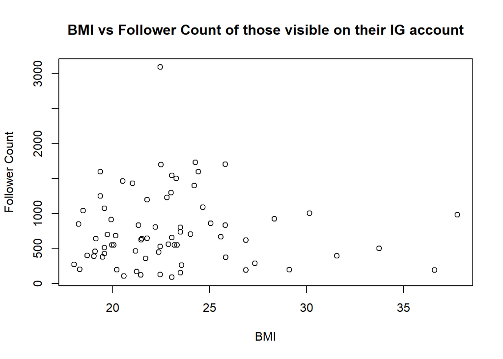

```
##
## Call:
## lm(formula = ig_posters$Followers ~ ig_posters$BMI, data = ig_posters)
##
## Residuals:
##    Min     1Q Median     3Q    Max
## -672.0 -376.0 -121.3  265.3 2329.8
##
## Coefficients:
##                Estimate Std. Error t value Pr(>|t|)
## (Intercept)     811.785    374.958   2.165   0.0338 *
## ig_posters$BMI   -2.162     16.035  -0.135   0.8931
## ---
## Signif. codes:  0 '***' 0.001 '**' 0.01 '*' 0.05 '.' 0.1 ' ' 1
##
## Residual standard error: 537.8 on 69 degrees of freedom
## Multiple R-squared:  0.0002633,  Adjusted R-squared:  -0.01423
## F-statistic: 0.01818 on 1 and 69 DF,  p-value: 0.8931
```

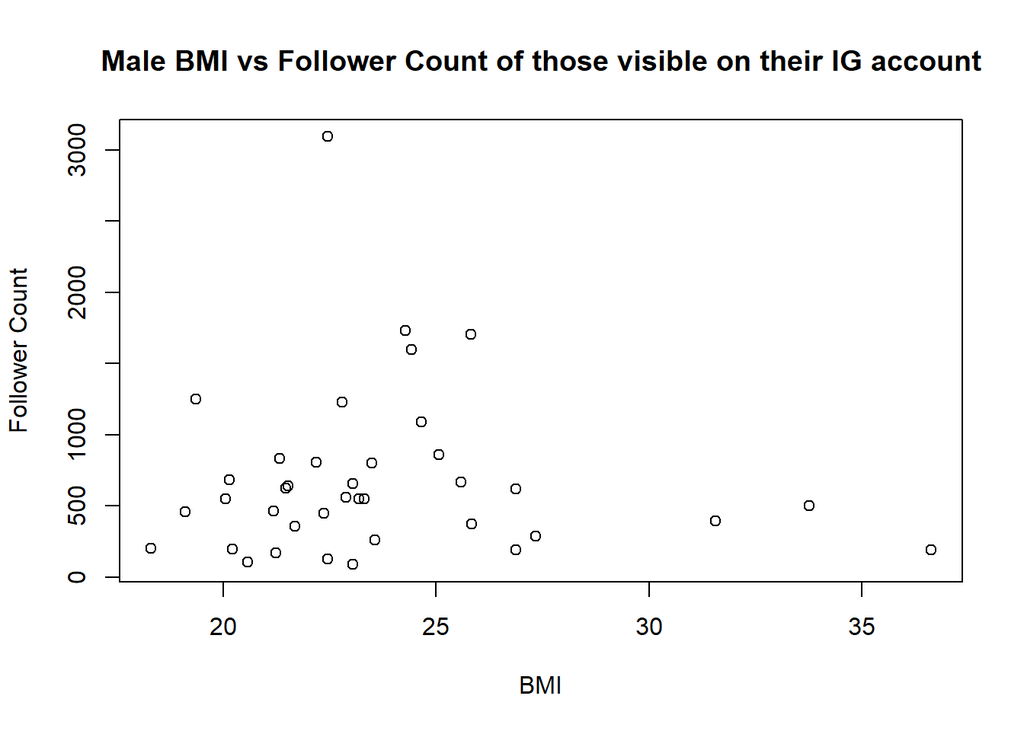

```
##
## Call:
## lm(formula = ig_postersMale$Followers ~ ig_postersMale$BMI, data = ig_postersMale)
##
## Residuals:
##    Min     1Q Median     3Q    Max
## -605.5 -355.6 -132.7  114.7 2399.2
##
## Coefficients:
##                    Estimate Std. Error t value Pr(>|t|)
## (Intercept)          892.83     614.45   1.453    0.155
## ig_postersMale$BMI    -8.86      25.63  -0.346    0.732
##
## Residual standard error: 594.1 on 36 degrees of freedom
## Multiple R-squared:  0.003309,   Adjusted R-squared:  -0.02438
## F-statistic: 0.1195 on 1 and 36 DF,  p-value: 0.7316
```

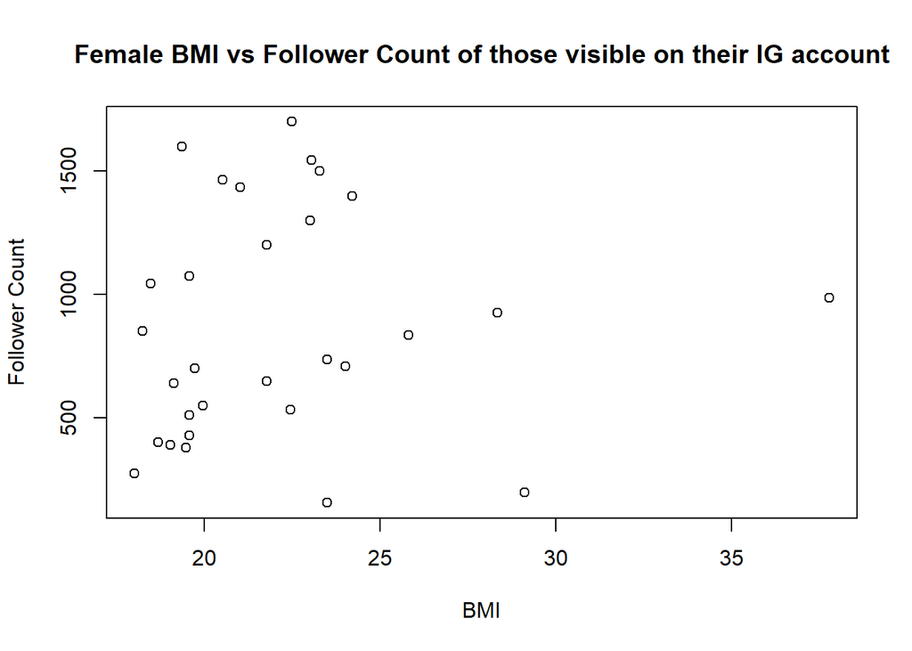

```
##
## Call:
## lm(formula = ig_postersFemale$Followers ~ ig_postersFemale$BMI,
##     data = ig_postersFemale)
##
## Residuals:
##    Min     1Q Median     3Q    Max
## -742.8 -339.2 -108.9  399.2  826.5
##
## Coefficients:
##                      Estimate Std. Error t value Pr(>|t|)
## (Intercept)           648.656    476.629   1.361    0.184
## ig_postersFemale$BMI    9.997     21.168   0.472    0.640
##
## Residual standard error: 466.3 on 28 degrees of freedom
## Multiple R-squared:  0.007903,   Adjusted R-squared:  -0.02753
## F-statistic: 0.223 on 1 and 28 DF,  p-value: 0.6404
```

Despite our best efforts to keep the sample representative of the population, there may be confounding variables at play here. Mainly, if one gender is more likely to post pictures of themselves on their Instagram accounts, this would result in the data not being independent. This is because men tend to have higher BMIs than women. Thus, we constructed a 95% confidence interval for the ratio of odds of males posting pictures of themselves on Instagram vs females posting pictures of themselves on Instagram to see if there’s evidence that males are more likely to post pictures of themselves on Instagram than females, or vice versa. The results of the Fisher’s test are shown below.

```
##
##  Fisher's Exact Test for Count Data
##
## data:  ig_posting_by_gender
## p-value = 0.006644
## alternative hypothesis: true odds ratio is not equal to 1
## 95 percent confidence interval:
##  0.06375243 0.72962556
## sample estimates:
## odds ratio
##  0.2377679
```

#### 2) Does BMI affect whether or not Instagram users post pictures of themselves on their Instagram?

We want to answer whether the mean BMI of individuals who don’t post pictures of themselves on their Instagram accounts is different from the mean BMI of individuals who do post pictures of themselves on their Instagram accounts. It’s important to aknowledge that body shaming can go both ways–it is something that people can unfortunately experience at high BMI’s as well as low BMI’s. Thus, this question will be answered by running a two-sample t-test for the difference of means with a 90% confidence level. To account for body shaming going both ways, this will be a two-sided hypothesis test. In other words, the null hypothesis is that the true difference in means between the two groups is equal to zero, and the alternative hypothesis is that the true difference is not equal to 0 (not necessarily just less than 0 or just greater than 0). We chose a 90% as our confidence level over a higher value like 95% or 99% because type 1 errors aren’t a concern–it wouldn’t be a huge problem if we claimed to have evidence of body shaming even though there is no body shaming in reality. At least, it wouldn’t be nearly as big of an issue compared to a type 2 error: claiming that there is no evidence of body shaming, when in reality, body shaming is present. In other words, we chose a 90% confidence level because having a lower confidence level reduces the probability of a type 2 error, which would be more detrimental in this case. Three hypothesis tests for this data were conducted. First, we ran the hypothesis tests for the difference of sample means for all respondents. Then, we ran the same tests for males and females separately. Much like in question 1, gender has the potential to be a confounding variable here, so when making conclusions using this hypothesis test, we’ll be sure to reference the confidence interval for the ratio of odds created in question 1.

```
##
##  Welch Two Sample t-test
##
## data:  ig_NonPosters$BMI and ig_posters$BMI
## t = 2.1151, df = 56.475, p-value = 0.03884
## alternative hypothesis: true difference in means is not equal to 0
## 90 percent confidence interval:
##  0.4162864 3.5603938
## sample estimates:
## mean of x mean of y
##  25.03070  23.04236
```

Critical value: ±1.6722855

```
##
##  Welch Two Sample t-test
##
## data:  ig_nonPostersMale$BMI and ig_postersMale$BMI
## t = 1.5404, df = 46.822, p-value = 0.1302
## alternative hypothesis: true difference in means is not equal to 0
## 90 percent confidence interval:
##  -0.1559469  3.6454584
## sample estimates:
## mean of x mean of y
##  25.42415  23.67939
```

Critical value: ±1.6780549

```
##
##  Welch Two Sample t-test
##
## data:  ig_nonPostersFemale$BMI and ig_postersFemale$BMI
## t = -0.31365, df = 14.695, p-value = 0.7582
## alternative hypothesis: true difference in means is not equal to 0
## 90 percent confidence interval:
##  -2.154404  1.501239
## sample estimates:
## mean of x mean of y
##  21.82789  22.15447
```

Critical value: ±1.7554422

#### 3) Does BMI affect whether or not individuals have an Instagram account?

This will be determined in a fashion very similar to question 2 above. We want to answer whether the mean BMI of individuals who don’t use Instagram is different from the mean BMI of individuals who do use Instagram. Thus, this question will be answered by running a two-sample t-test for the difference of means with a 90% confidence level. Once again, the t-test will be two-sided, since body shaming goes both ways, and a lower confidence level of 90% is used because a type 2 error is more detrimental than a type 1 error for the purposes of this study. The results of the t-tests are shown below. Once again, three different tests were conducted: one for all respondents, one for the male respondents, and one for the female respondents.

```
##
##  Welch Two Sample t-test
##
## data:  nonIg_users$BMI and ig_users$BMI
## t = -2.0665, df = 52.798, p-value = 0.04371
## alternative hypothesis: true difference in means is not equal to 0
## 90 percent confidence interval:
##  -2.8807735 -0.3020627
## sample estimates:
## mean of x mean of y
##  22.09479  23.68620
```

Critical value: ±1.6742304

```
##
##  Welch Two Sample t-test
##
## data:  nonIg_usersMale$BMI and ig_usersMale$BMI
## t = -2.022, df = 41.477, p-value = 0.04966
## alternative hypothesis: true difference in means is not equal to 0
## 90 percent confidence interval:
##  -3.485607 -0.319529
## sample estimates:
## mean of x mean of y
##  22.50157  24.40413
```

Critical value: ±1.6824311

```
##
##  Welch Two Sample t-test
##
## data:  nonIg_usersFemale$BMI and ig_usersFemale$BMI
## t = -1.4367, df = 8.9485, p-value = 0.1848
## alternative hypothesis: true difference in means is not equal to 0
## 90 percent confidence interval:
##  -4.149646  0.504470
## sample estimates:
## mean of x mean of y
##  20.28523  22.10782
```

Critical value: ±1.8343155

Much like in questions 1 and 2, gender could be a confounding variable here. To account for this, a 95% confidence interval is created for the ratio of odds of male Instagram usage vs females Instagram usage. The results of the Fisher’s test are shown below.

```
##
##  Fisher's Exact Test for Count Data
##
## data:  ig_usage_by_gender
## p-value = 0.2514
## alternative hypothesis: true odds ratio is not equal to 1
## 95 percent confidence interval:
##  0.160775 1.532429
## sample estimates:
## odds ratio
##  0.5330903
```

#### 4) Does the daily time spent on Instagram affect an individual’s GPA?

We want to answer whether an increase in daily time spent on Instagram causes a significant increase or decrease in GPA. To determine this, linear regression can once again be used to see if there’s a trend in the collected data. Below, a plot of daily time spent on Instagram in minutes vs GPA is given for the sampled group of all Instagram users. This is followed by the results of fitting a linear model to this relationship, where the independent variable is daily time spent on Instagram, and the dependent variable is GPA.

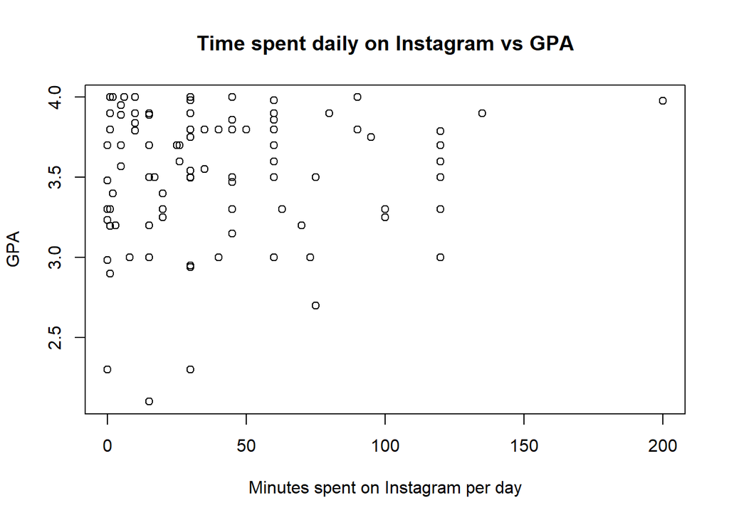

```
##
## Call:
## lm(formula = ig_users$GPA ~ ig_users$MinsOnIG, data = ig_users)
##
## Residuals:
##      Min       1Q   Median       3Q      Max
## -1.39828 -0.24168  0.08193  0.30181  0.52021
##
## Coefficients:
##                   Estimate Std. Error t value Pr(>|t|)
## (Intercept)       3.478471   0.059420   58.54   <2e-16 ***
## ig_users$MinsOnIG 0.001320   0.001074    1.23    0.222
## ---
## Signif. codes:  0 '***' 0.001 '**' 0.01 '*' 0.05 '.' 0.1 ' ' 1
##
## Residual standard error: 0.4127 on 101 degrees of freedom
## Multiple R-squared:  0.01475,    Adjusted R-squared:  0.004992
## F-statistic: 1.512 on 1 and 101 DF,  p-value: 0.2217
```

#### 5) Does having an Instagram account affect an individual’s GPA?

Determining the answer to this question will involve another confidence interval. We want to determine whether the mean GPA of U of U students who have an Instagram is less than the mean GPA of those who do not have an Instagram. Thus, a two-sample t-test for the difference of means will be conducted. Unlike the previous two t-tests, this one will be a one sided test. We are specifically looking for evidence that the mean GPA of Instagram users is less than the mean GPA of those who don’t user Instagram. So, the null hypothesis is that the difference in mean GPA of U of U students who use Instagram and those who don’t is greater than or equal to 0, and the alternative hypothesis is that this difference is less than 0. Also, for this test, we chose a confidence level of 95%–this is a higher confidence level than the other two t-tests conducted. This is because the difference in severity for type 1 and type 2 errors isn’t as prominent here. We don’t want to fail to reject the null hypothesis when it is false, but on the other hand, we don’t want to tell students to further limit their Instagram usage if it doesn’t actually affect their GPA. Especially with COVID, Instagram has the ability to let students socialize with people that they may not be able to see in-person. This is not something we want to limit for no good reason. The results of the t-test are shown below.

```
##
##  Welch Two Sample t-test
##
## data:  as.numeric(ig_users$GPA) and as.numeric(nonIg_users$GPA)
## t = -2.0385, df = 51.664, p-value = 0.02331
## alternative hypothesis: true difference in means is less than 0
## 95 percent confidence interval:
##         -Inf -0.02739135
## sample estimates:
## mean of x mean of y
##  3.531738  3.685286
```

Critical value: -1.6748864

## Conclusions

Our first body-shaming related question sought to use the activity of Instagram users to determine if there’s evidence of body shaming on the platform. In particular, if there was a clear correlation between BMI and follower count of students who post pictures of themselves on Instagram, this could be an obvious indicator of body shaming on the platform among U of U students. When we fitted linear models to the data of BMI vs follower count, there was no evidence that an increase in BMI correlates to a clear increase or decrease in follower count. This was the case regardless of whether or not the data was split by gender. For all genders combined, the r^2 value was 0.0002633. For males, the r^2 values was 0.003309, and for females, the r^2 value was 0.007903. Thus, the data we collected does not provide evidence that there is a significant correlation between U of U students’ BMIs and their follower counts on Instagram if they post pictures of themselves on Instagram.

Our next question sought to determine if BMI affected whether or not Instagram users posted pictures of themselves on their Instagram accounts. If there is a significant difference between the mean BMI of users who do post pictures of themselves on their Instagram account and the mean BMI of Instagram users who don’t post pictures of themselves on their accounts, this could be another sign of body shaming on the platform. Our first t-test with a 90% confidence level for this question involved all genders, and it did in fact show that there is a significant difference between the two sample means. The confidence interval for the difference of means was from 0.4162864 to 3.5603938. The p-value was 0.03884, which is less than the alpha value of 0.1, and the t-statistic was 2.1151, which exceeds the critical value of 1.672286 for this test. Thus, based on this test, we are 90% confident that the mean BMI of U of U students who post pictures of themselves on Instagram is significantly different from the mean BMI of U of U Instagram users who don’t post pictures of themselves on Instagram.

Oddly enough, the same t-tests did not yield significant differences between the two means when conducted using the data separated by gender. The confidence interval for males was from -0.1559469 to 3.6454584, and for females, it was from -2.154404 to 1.501239. The magnitudes of the t-statistics for males, 1.5404, and females, 0.31365, were both less than their critical values of 1.678055 and 1.755443 respectively. As discussed earlier, gender could be a confounding variable here. This is why we conducted a Fisher’s test for the odds ratio for males posting pictures of themselves on Instagram vs females posting pictures of themselves on Instagram. The results of the test yielded a confidence interval from 0.06375243 to 0.72962556, and a p-value of 0.006644, which is less than the alpha value of 0.05. Thus, we have enough evidence to reject the null hypothesis that the true odds ratio is equal to 1, and are 95% confident that the true odds ratio is not equal to 1. This sample in particular showed that women were far more likely to post pictures of themselves on their Instagram accounts than men. This could explain the discrepancy between the results of the t-tests comparing BMI of Instagram users who do or don’t post pictures of themselves on Instagram when separated by gender. Because we found that women were more likely to post pictures of themselves on Instagram, the original t-test involving all genders comparing BMI of Instagram users who do or don’t post pictures of themselves on Instagram may not be valid–the samples aren’t necessarily independent and identically distributed. The results of the Fisher’s test may not be perfect either, because there were significantly more male respondents than female respondents. For this Fisher’s test in particular, there were 65 male Instagram users, and 35 female Instagram users. Regardless, the results of the test can explain the discrepancy for the t-tests conducted for question 2.

Question 3 was similar to question 2, but instead asked if BMI affected whether or not U of U students even had an Instagram account in the first place. If there is a significant difference between the mean BMI of U of U students who don’t use Instagram and the mean BMI of U of U students who do use Instagram, this could be another sign of body shaming on the platform. Like in question 2, our first 2-sided t-test with a confidence level of 90% for this question involved all genders, at it did in fact show a significant difference between the two sample means. The confidence interval for the difference of means was from -2.8807735 -0.3020627. The p-value was 0.04371, which is less than the alpha value of 0.1, and the magnitude of the t-statistic was 2.0665, which exceeds the critical value of 1.67423 for this test. Thus, based on this test, we are 90% confident that the mean BMI of U of U students who don’t use Instagram is significantly different from the mean BMI of U of U students who do use Instagram.

Our next two questions dealt with Instagram’s effect on U of U students’ performance in school. Question 4 was rather straightforward: we simply tested whether or not there was a correlation between Instagram users’ time spent on Instagram per day and their GPA. Fitting a linear model to the data of time spent on Instagram vs GPA did not show any evidence that there is a correlation between the two. The r^2 value was 0.01475, which was rather small. Thus, we don’t have evidence to conclude that time spent on Instagram significantly affects GPA. However, the data may not be independent and identically distributed. There could be other factors affecting respondents’ GPAs. Mainly, students in different majors may have different GPAs. We did not take this into account when collecting the data, so we have no way of knowing whether or not a student’s major affected their GPA. However, our sample was quite large, since we collected responses from 105 Instagram users, so we should have seen representation from several different majors. That being said, because of the discord servers that we posted this survey on, including this class’s discord server, CS and other STEM majors may be over represented in the sample.

Question 5 involved conducting another t-test to determine whether having an Instagram account affected a student’s GPA. Based on the results from question 4, one would expect that we wouldn’t see a significant difference between the two sample means, since we weren’t able to prove that there’s a correlation between time spent on Instagram and GPA. However, the results of the t-test do in fact show a significant difference between the sample means. The one-sided 95% t-test yielded a confidence interval from -$\infty$ to -0.02739135, a p-value of 0.02331, which is less than the alpha value of 0.05, and a t-statistic of -2.0385, which is less than the critical value of -1.6748864. Thus, we have enough evidence to reject the null hypothesis that the true difference in means is greater than or equal to zero. We are 95% confident that the mean GPA of U of U students who use Instagram is less than the mean GPA of U of U students who do not use Instagram. This seems like it conflicts with our conclusions from question 4. After all, the linear model did not show that students who spent 0 minutes per day tend to have a higher GPA than those who spend more time per day on Instagram. However, question 5 involved part of the sample that question 4 did not use, which was the group of students who didn’t even have an Instagram account. For this study, having an Instagram account but spending 0 minutes per day on Instagram is different from not having an Instagram at all. Despite this, there may be other reasons to call the results of this t-test into question. As discussed in question 4, students’ majors could be a confounding variable. In addition to this, the sample size of students who don’t use Instagram is much smaller than the sample size of students who use Instagram. We collected responses from 105 students who do use Instagram, but only 28 responses from students who don’t use Instagram. Because of the smaller sample size for the latter, the sample mean GPA for the non-Instagram users is less likely to be close to the true population mean GPA due to the law of large numbers. Thus, the results of this t-test must be taken with a grain of salt.

In conclusion, we were able to find evidence of body shaming on Instagram in questions 2 and 3, as well as evidence of Instagram usage affecting U of U student performance in question 5. But, for each of these questions, our conclusions are imperfect due to our sampling methods. For questions 1-3, the difference between the number of male respondents and female respondents proved to be problematic in drawing clear conclusions. This is because these questions used BMI as a metric for students’ body types, which is a metric that is dependent on gender. As for questions 4 and 5, not taking students’ majors into account and the over representation of STEM majors could make our conclusions less valid. Also, for all questions, it would have helped if we had received a more even distribution of respondents who do use Instagram and respondents who don’t use Instagram. If this study were to be repeated, perhaps some sort of stratified or cluster sampling would help. This way, we could have the same number of male and female respondents, the same number of responses from people who do and don’t use Instagram, the same number of responses from people who use Instagram and post pictures of themselves and people who use Instagram and don’t post pictures of themselves, etc. Regardless, despite the imperfections of this study, we still have some evidence to suggest that Instagram may be negatively affecting U of U students.